# Can You Predict Life Expectancy At Birth For Different Countries?

In this project, I aim to understand whether we can accurately predict the life expectancy at birth for different countries based on different attributes like social support, life ladder, perceptions of corruption, and more. Understanding the relationship between such factors can help governments and policymakers have a better understanding of how the quality of life and health of its citizens are impacted by the policies they formulate. The contents that follow consists of applying different machine learning models and techniques on `World Happiness Report` dataset and understanding the relationship between the different variables in the dataset.

Click on the links if you want to navigate to a specific section.

1. Renaming the columns
2. Exploratory data analysis
3. Sampling
4. Detecting outliers
5. Visualization
6. Model training
   - Multiple regression
   - Linear regression
   - Analysis of regression models
   - Decision Tree Regressor
   - Gradient Boosting Trees
   - Random Forest
7. Overall Analysis

### Importing Packages

Importing relevant packages for analysis.

```python
import pandas as pd
import numpy as np
import os
import matplotlib.pyplot as plt
import seaborn as sns
```

```python
import scipy.stats as stats

#For linear regression
from sklearn.linear_model import LinearRegression
from sklearn.model_selection import train_test_split,  GridSearchCV
from sklearn.metrics import mean_squared_error, r2_score

#Decision tree regressor
from sklearn.tree import DecisionTreeRegressor

#Ensemble techniques
from sklearn.ensemble import GradientBoostingRegressor
from sklearn.ensemble import RandomForestRegressor
```

### Loading the Data Set

I will be using the World Happiness Report dataset to conduct my analysis. This dataset can provide valuable insights because it allows us to see which factors impact the quality of life in different countries and how this impact affects the life expectancy at birth.

```python
#Importing the file into the dataframe
filename = os.path.join(os.getcwd(), "data", "WHR2018Chapter2OnlineData.csv")
df = pd.read_csv(filename, header = 0)
```

```python
# Viewing the dataframe (First ten columns)
print("Initial 10 rows of the dataframe")
print("-------------------------------------------------------")
df.head(n = 11)
```

```
Initial 10 rows of the dataframe
-------------------------------------------------------
```

|  | country | year | Life Ladder | Log GDP per capita | Social support | Healthy life expectancy at birth | Freedom to make life choices | Generosity | Perceptions of corruption | Positive affect | Negative affect | Confidence in national government | Democratic Quality | Delivery Quality | Standard deviation of ladder by country-year | Standard deviation/Mean of ladder by country-year | GINI index (World Bank estimate) | GINI index (World Bank estimate), average 2000-15 | gini of household income reported in Gallup, by wp5-year |
| --- | --- | --- | --- | --- | --- | --- | --- | --- | --- | --- | --- | --- | --- | --- | --- | --- | --- | --- | --- |
| 0 | Afghanistan | 2008 | 3.723590 | 7.168690 | 0.450662 | 49.209663 | 0.718114 | 0.181819 | 0.881686 | 0.517637 | 0.258195 | 0.612072 | -1.929690 | -1.655084 | 1.774662 | 0.476600 | NaN | NaN | NaN |
| 1 | Afghanistan | 2009 | 4.401778 | 7.333790 | 0.552308 | 49.624432 | 0.678896 | 0.203614 | 0.850035 | 0.583926 | 0.237092 | 0.611545 | -2.044093 | -1.635025 | 1.722688 | 0.391362 | NaN | NaN | 0.441906 |
| 2 | Afghanistan | 2010 | 4.758381 | 7.386629 | 0.539075 | 50.008961 | 0.600127 | 0.137630 | 0.706766 | 0.618265 | 0.275324 | 0.299357 | -1.991810 | -1.617176 | 1.878622 | 0.394803 | NaN | NaN | 0.327318 |
| 3 | Afghanistan | 2011 | 3.831719 | 7.415019 | 0.521104 | 50.367298 | 0.495901 | 0.175329 | 0.731109 | 0.611387 | 0.267175 | 0.307386 | -1.919018 | -1.616221 | 1.785360 | 0.465942 | NaN | NaN | 0.336764 |
| 4 | Afghanistan | 2012 | 3.782938 | 7.517126 | 0.520637 | 50.709263 | 0.530935 | 0.247159 | 0.775620 | 0.710385 | 0.267919 | 0.435440 | -1.842996 | -1.404078 | 1.798283 | 0.475367 | NaN | NaN | 0.344540 |
| 5 | Afghanistan | 2013 | 3.572100 | 7.503376 | 0.483552 | 51.042980 | 0.577955 | 0.074735 | 0.823204 | 0.620585 | 0.273328 | 0.482847 | -1.879709 | -1.403036 | 1.223690 | 0.342569 | NaN | NaN | 0.304368 |
| 6 | Afghanistan | 2014 | 3.130896 | 7.484583 | 0.525568 | 51.370525 | 0.508514 | 0.118579 | 0.871242 | 0.531691 | 0.374861 | 0.409048 | -1.773257 | -1.312503 | 1.395396 | 0.445686 | NaN | NaN | 0.413974 |
| 7 | Afghanistan | 2015 | 3.982855 | 7.466215 | 0.528597 | 51.693527 | 0.388928 | 0.094686 | 0.880638 | 0.553553 | 0.339276 | 0.260557 | -1.844364 | -1.291594 | 2.160618 | 0.542480 | NaN | NaN | 0.596918 |
| 8 | Afghanistan | 2016 | 4.220169 | 7.461401 | 0.559072 | 52.016529 | 0.522566 | 0.057072 | 0.793246 | 0.564953 | 0.348332 | 0.324990 | -1.917693 | -1.432548 | 1.796219 | 0.425627 | NaN | NaN | 0.418629 |
| 9 | Afghanistan | 2017 | 2.661718 | 7.460144 | 0.490880 | 52.339527 | 0.427011 | -0.106340 | 0.954393 | 0.496349 | 0.371326 | 0.261179 | NaN | NaN | 1.454051 | 0.546283 | NaN | NaN | 0.286599 |
| 10 | Albania | 2007 | 4.634252 | 9.077325 | 0.821372 | 66.576630 | 0.528605 | -0.016183 | 0.874700 | 0.552678 | 0.246335 | 0.300681 | -0.045108 | -0.420024 | 1.764947 | 0.380848 | NaN | 0.30325 | NaN |

```python
df.shape
```

```
(1562, 19)
```

I observe that the dataset is more of a timeseries for each country listed within the dataset. So I might have to structure my approach around whether I would like to go for a more year-by-year country-specific analysis or would I go for analyzing the entire dataset.

As of now, I think that I've chosen a difficult dataset because if I choose to focus on just a few years, then the number of data entries I can analyze will be significantly low.

### Implementing My Project Plan

This notebook implements some elements of CRISP-DM framework for data modeling. I begin exploring the data with feature engineering and data visualization. Next, I model the data using different regression models and analyze the accuracy scores. Finally, I modify hyperparameters and analyze which models are top candidates for this problem set.

## Please Note:

A lot of the text that I write is to guide myself through understanding the concepts we've covered so far. So you might find a lot of "Note to myself" type of comments and I hope I don't trouble you with them.

## Renaming the columns

```python
columns_renamed = {'Life Ladder': 'life_ladder', 'Log GDP per capita': 'log_GDP_per_capita' ,
       'Social support' : 'social_support', 'Healthy life expectancy at birth': "life_expectancy",
       'Freedom to make life choices': 'freedom_choices', 'Generosity': 'generosity',
       'Perceptions of corruption' : "corruption_perception", 'Positive affect': 'positive_effect', 'Negative affect': 'negative_effect',
       'Confidence in national government' : 'government_confidence', 'Democratic Quality': 'democratic_quality',
       'Delivery Quality': 'delivery_quality', 'Standard deviation of ladder by country-year': 'ladder_standard_deviation',
       'Standard deviation/Mean of ladder by country-year': "mean_of_ladder",
       'GINI index (World Bank estimate)': "gini_WB",
       'GINI index (World Bank estimate), average 2000-15': 'gini_avg',
       'gini of household income reported in Gallup, by wp5-year': 'gini_gallup_5yr'}

df.rename(columns = columns_renamed, inplace = True)
df.head()
```

|  | country | year | life_ladder | log_GDP_per_capita | social_support | life_expectancy | freedom_choices | generosity | corruption_perception | positive_effect | negative_effect | government_confidence | democratic_quality | delivery_quality | ladder_standard_deviation | mean_of_ladder | gini_WB | gini_avg | gini_gallup_5yr |
| --- | --- | --- | --- | --- | --- | --- | --- | --- | --- | --- | --- | --- | --- | --- | --- | --- | --- | --- | --- |
| 0 | Afghanistan | 2008 | 3.723590 | 7.168690 | 0.450662 | 49.209663 | 0.718114 | 0.181819 | 0.881686 | 0.517637 | 0.258195 | 0.612072 | -1.929690 | -1.655084 | 1.774662 | 0.476600 | NaN | NaN | NaN |
| 1 | Afghanistan | 2009 | 4.401778 | 7.333790 | 0.552308 | 49.624432 | 0.678896 | 0.203614 | 0.850035 | 0.583926 | 0.237092 | 0.611545 | -2.044093 | -1.635025 | 1.722688 | 0.391362 | NaN | NaN | 0.441906 |
| 2 | Afghanistan | 2010 | 4.758381 | 7.386629 | 0.539075 | 50.008961 | 0.600127 | 0.137630 | 0.706766 | 0.618265 | 0.275324 | 0.299357 | -1.991810 | -1.617176 | 1.878622 | 0.394803 | NaN | NaN | 0.327318 |
| 3 | Afghanistan | 2011 | 3.831719 | 7.415019 | 0.521104 | 50.367298 | 0.495901 | 0.175329 | 0.731109 | 0.611387 | 0.267175 | 0.307386 | -1.919018 | -1.616221 | 1.785360 | 0.465942 | NaN | NaN | 0.336764 |
| 4 | Afghanistan | 2012 | 3.782938 | 7.517126 | 0.520637 | 50.709263 | 0.530935 | 0.247159 | 0.775620 | 0.710385 | 0.267919 | 0.435440 | -1.842996 | -1.404078 | 1.798283 | 0.475367 | NaN | NaN | 0.344540 |

Note to myself: Remember to use inplace = True also remember to use columns = (as in the function parameters)

### Creating my own label for data analysis and model prediction

I realized that the data does not specifically have a categorical label and I wanted to try how to predict the model in terms of categorical variables.

```python
# Glancing through the dataset
df.loc[df['life_expectancy'] <= 60]
```

|  | country | year | life_ladder | log_GDP_per_capita | social_support | life_expectancy | freedom_choices | generosity | corruption_perception | positive_effect | negative_effect | government_confidence | democratic_quality | delivery_quality | ladder_standard_deviation | mean_of_ladder | gini_WB | gini_avg | gini_gallup_5yr |
| --- | --- | --- | --- | --- | --- | --- | --- | --- | --- | --- | --- | --- | --- | --- | --- | --- | --- | --- | --- |
| 0 | Afghanistan | 2008 | 3.723590 | 7.168690 | 0.450662 | 49.209663 | 0.718114 | 0.181819 | 0.881686 | 0.517637 | 0.258195 | 0.612072 | -1.929690 | -1.655084 | 1.774662 | 0.476600 | NaN | NaN | NaN |
| 1 | Afghanistan | 2009 | 4.401778 | 7.333790 | 0.552308 | 49.624432 | 0.678896 | 0.203614 | 0.850035 | 0.583926 | 0.237092 | 0.611545 | -2.044093 | -1.635025 | 1.722688 | 0.391362 | NaN | NaN | 0.441906 |
| 2 | Afghanistan | 2010 | 4.758381 | 7.386629 | 0.539075 | 50.008961 | 0.600127 | 0.137630 | 0.706766 | 0.618265 | 0.275324 | 0.299357 | -1.991810 | -1.617176 | 1.878622 | 0.394803 | NaN | NaN | 0.327318 |
| 3 | Afghanistan | 2011 | 3.831719 | 7.415019 | 0.521104 | 50.367298 | 0.495901 | 0.175329 | 0.731109 | 0.611387 | 0.267175 | 0.307386 | -1.919018 | -1.616221 | 1.785360 | 0.465942 | NaN | NaN | 0.336764 |
| 4 | Afghanistan | 2012 | 3.782938 | 7.517126 | 0.520637 | 50.709263 | 0.530935 | 0.247159 | 0.775620 | 0.710385 | 0.267919 | 0.435440 | -1.842996 | -1.404078 | 1.798283 | 0.475367 | NaN | NaN | 0.344540 |
| ... | ... | ... | ... | ... | ... | ... | ... | ... | ... | ... | ... | ... | ... | ... | ... | ... | ... | ... | ... |
| 1557 | Zimbabwe | 2013 | 4.690188 | 7.565154 | 0.799274 | 48.949745 | 0.575884 | -0.076716 | 0.830937 | 0.711885 | 0.182288 | 0.527755 | -1.026085 | -1.526321 | 1.964805 | 0.418918 | NaN | 0.432 | 0.555439 |
| 1558 | Zimbabwe | 2014 | 4.184451 | 7.562753 | 0.765839 | 50.051235 | 0.642034 | -0.045885 | 0.820217 | 0.725214 | 0.239111 | 0.566209 | -0.985267 | -1.484067 | 2.079248 | 0.496899 | NaN | 0.432 | 0.601080 |
| 1559 | Zimbabwe | 2015 | 3.703191 | 7.556052 | 0.735800 | 50.925652 | 0.667193 | -0.094585 | 0.810457 | 0.715079 | 0.178861 | 0.590012 | -0.893078 | -1.357514 | 2.198865 | 0.593776 | NaN | 0.432 | 0.655137 |
| 1560 | Zimbabwe | 2016 | 3.735400 | 7.538829 | 0.768425 | 51.800068 | 0.732971 | -0.065283 | 0.723612 | 0.737636 | 0.208555 | 0.699344 | -0.863044 | -1.371214 | 2.776363 | 0.743257 | NaN | 0.432 | 0.596690 |
| 1561 | Zimbabwe | 2017 | 3.638300 | 7.538187 | 0.754147 | 52.674484 | 0.752826 | -0.066005 | 0.751208 | 0.806428 | 0.224051 | 0.682647 | NaN | NaN | 2.656848 | 0.730244 | NaN | 0.432 | 0.581484 |

473 rows × 19 columns

```python
# Using np.select worked. Previously when I used just the
conditions = [(df['life_expectancy'] > 70),
              (df['life_expectancy'] <= 70)
             ]
values = ['>70', '<=70']
df['life_expectancy_label'] = np.select(conditions, values)
```

```python
# Checking if my code worked
condition = (df['life_expectancy_label'] == "<=70")
df[condition]
```

|  | country | year | life_ladder | log_GDP_per_capita | social_support | life_expectancy | freedom_choices | generosity | corruption_perception | positive_effect | negative_effect | government_confidence | democratic_quality | delivery_quality | ladder_standard_deviation | mean_of_ladder | gini_WB | gini_avg | gini_gallup_5yr | life_expectancy_label |
| --- | --- | --- | --- | --- | --- | --- | --- | --- | --- | --- | --- | --- | --- | --- | --- | --- | --- | --- | --- | --- |
| 0 | Afghanistan | 2008 | 3.723590 | 7.168690 | 0.450662 | 49.209663 | 0.718114 | 0.181819 | 0.881686 | 0.517637 | 0.258195 | 0.612072 | -1.929690 | -1.655084 | 1.774662 | 0.476600 | NaN | NaN | NaN | <=70 |
| 1 | Afghanistan | 2009 | 4.401778 | 7.333790 | 0.552308 | 49.624432 | 0.678896 | 0.203614 | 0.850035 | 0.583926 | 0.237092 | 0.611545 | -2.044093 | -1.635025 | 1.722688 | 0.391362 | NaN | NaN | 0.441906 | <=70 |
| 2 | Afghanistan | 2010 | 4.758381 | 7.386629 | 0.539075 | 50.008961 | 0.600127 | 0.137630 | 0.706766 | 0.618265 | 0.275324 | 0.299357 | -1.991810 | -1.617176 | 1.878622 | 0.394803 | NaN | NaN | 0.327318 | <=70 |
| 3 | Afghanistan | 2011 | 3.831719 | 7.415019 | 0.521104 | 50.367298 | 0.495901 | 0.175329 | 0.731109 | 0.611387 | 0.267175 | 0.307386 | -1.919018 | -1.616221 | 1.785360 | 0.465942 | NaN | NaN | 0.336764 | <=70 |
| 4 | Afghanistan | 2012 | 3.782938 | 7.517126 | 0.520637 | 50.709263 | 0.530935 | 0.247159 | 0.775620 | 0.710385 | 0.267919 | 0.435440 | -1.842996 | -1.404078 | 1.798283 | 0.475367 | NaN | NaN | 0.344540 | <=70 |
| ... | ... | ... | ... | ... | ... | ... | ... | ... | ... | ... | ... | ... | ... | ... | ... | ... | ... | ... | ... | ... |
| 1557 | Zimbabwe | 2013 | 4.690188 | 7.565154 | 0.799274 | 48.949745 | 0.575884 | -0.076716 | 0.830937 | 0.711885 | 0.182288 | 0.527755 | -1.026085 | -1.526321 | 1.964805 | 0.418918 | NaN | 0.432 | 0.555439 | <=70 |
| 1558 | Zimbabwe | 2014 | 4.184451 | 7.562753 | 0.765839 | 50.051235 | 0.642034 | -0.045885 | 0.820217 | 0.725214 | 0.239111 | 0.566209 | -0.985267 | -1.484067 | 2.079248 | 0.496899 | NaN | 0.432 | 0.601080 | <=70 |
| 1559 | Zimbabwe | 2015 | 3.703191 | 7.556052 | 0.735800 | 50.925652 | 0.667193 | -0.094585 | 0.810457 | 0.715079 | 0.178861 | 0.590012 | -0.893078 | -1.357514 | 2.198865 | 0.593776 | NaN | 0.432 | 0.655137 | <=70 |
| 1560 | Zimbabwe | 2016 | 3.735400 | 7.538829 | 0.768425 | 51.800068 | 0.732971 | -0.065283 | 0.723612 | 0.737636 | 0.208555 | 0.699344 | -0.863044 | -1.371214 | 2.776363 | 0.743257 | NaN | 0.432 | 0.596690 | <=70 |
| 1561 | Zimbabwe | 2017 | 3.638300 | 7.538187 | 0.754147 | 52.674484 | 0.752826 | -0.066005 | 0.751208 | 0.806428 | 0.224051 | 0.682647 | NaN | NaN | 2.656848 | 0.730244 | NaN | 0.432 | 0.581484 | <=70 |

1267 rows × 20 columns

```python
condition1 = (df['life_expectancy_label'] == "<=70")
print("Number of rows with life expectancy less than or equal to 70 = " + str(df[condition1].shape[0]))

condition2 = (df['life_expectancy_label'] == ">70")
print("Number of rows with life expectancy greater than 70 = " + str(df[condition2].shape[0]))
```

```
Number of rows with life expectancy less than or equal to 70 = 1267
Number of rows with life expectancy greater than 70 = 286
```

## Exploratory Data Analysis

Learning more about the spread of the data using describe(). This step allows me to check whether there are any outliers that I should be handling before sending the data into the modeling phase.

```python
df.describe()
```

|  | year | life_ladder | log_GDP_per_capita | social_support | life_expectancy | freedom_choices | generosity | corruption_perception | positive_effect | negative_effect | government_confidence | democratic_quality | delivery_quality | ladder_standard_deviation | mean_of_ladder | gini_WB | gini_avg | gini_gallup_5yr |
| --- | --- | --- | --- | --- | --- | --- | --- | --- | --- | --- | --- | --- | --- | --- | --- | --- | --- | --- |
| count | 1562.000000 | 1562.000000 | 1535.000000 | 1549.000000 | 1553.000000 | 1533.000000 | 1482.000000 | 1472.000000 | 1544.000000 | 1550.000000 | 1401.000000 | 1391.000000 | 1391.000000 | 1562.000000 | 1562.000000 | 583.000000 | 1386.000000 | 1205.000000 |
| mean | 2011.820743 | 5.433676 | 9.220822 | 0.810669 | 62.249887 | 0.728975 | 0.000079 | 0.753622 | 0.708969 | 0.263171 | 0.480207 | -0.126617 | 0.004947 | 2.003501 | 0.387271 | 0.372846 | 0.386948 | 0.445204 |
| std | 3.419787 | 1.121017 | 1.184035 | 0.119370 | 7.960671 | 0.145408 | 0.164202 | 0.185538 | 0.107644 | 0.084006 | 0.190724 | 0.873259 | 0.981052 | 0.379684 | 0.119007 | 0.086609 | 0.083694 | 0.105410 |
| min | 2005.000000 | 2.661718 | 6.377396 | 0.290184 | 37.766476 | 0.257534 | -0.322952 | 0.035198 | 0.362498 | 0.083426 | 0.068769 | -2.448228 | -2.144974 | 0.863034 | 0.133908 | 0.241000 | 0.228833 | 0.223470 |
| 25% | 2009.000000 | 4.606351 | 8.310665 | 0.748304 | 57.299580 | 0.633754 | -0.114313 | 0.697359 | 0.621471 | 0.204116 | 0.334732 | -0.772010 | -0.717463 | 1.737934 | 0.309722 | 0.307000 | 0.321583 | 0.368531 |
| 50% | 2012.000000 | 5.332600 | 9.398610 | 0.833047 | 63.803192 | 0.748014 | -0.022638 | 0.808115 | 0.717398 | 0.251798 | 0.463137 | -0.225939 | -0.210142 | 1.960345 | 0.369751 | 0.349000 | 0.371000 | 0.425395 |
| 75% | 2015.000000 | 6.271025 | 10.190634 | 0.904329 | 68.098228 | 0.843628 | 0.094649 | 0.880089 | 0.800858 | 0.311515 | 0.610723 | 0.665944 | 0.717996 | 2.215920 | 0.451833 | 0.433500 | 0.433104 | 0.508579 |
| max | 2017.000000 | 8.018934 | 11.770276 | 0.987343 | 76.536362 | 0.985178 | 0.677773 | 0.983276 | 0.943621 | 0.704590 | 0.993604 | 1.540097 | 2.184725 | 3.527820 | 1.022769 | 0.648000 | 0.626000 | 0.961435 |

### Sampling

I'm performing sampling here as it allows me to drop or fill na columns with mean values and compare this subset with my original dataset.

```python
# Performing sampling

# Taking a percentage
percentage = 0.4
# Getting the number of rows
rows = df.shape[0]
# Using subset feature of pandas using sample()
df_sample = df.sample(int(percentage*rows))

df_sample.shape
```

```
(624, 20)
```

Note to myself: You need to add int() for the parameters of pd.sample() functions because they give the error `ValueError: Only integers accepted as`n`values` if you don't.

```python
## Using filters to check for specific columns
df_sample['country'].value_counts()
```

```
Tajikistan        10
Kosovo            10
Uganda             8
Sri Lanka          7
Brazil             7
                  ..
Ivory Coast        1
South Sudan        1
Czech Republic     1
Guyana             1
Bhutan             1
Name: country, Length: 161, dtype: int64
```

Some countries have only one or two entries within the dataset and some have >=8

### Detecting outliers

#### Approach 1 - Drop rows with NA in gini_WB

For np.percentile() to work, the column should not contain NA or NaN values. So my first approach is to drop rows that contain NaN in them

```python
df_dropped = df_sample.dropna(subset = ['gini_WB'])
df_dropped
```

|  | country | year | life_ladder | log_GDP_per_capita | social_support | life_expectancy | freedom_choices | generosity | corruption_perception | positive_effect | negative_effect | government_confidence | democratic_quality | delivery_quality | ladder_standard_deviation | mean_of_ladder | gini_WB | gini_avg | gini_gallup_5yr | life_expectancy_label |
| --- | --- | --- | --- | --- | --- | --- | --- | --- | --- | --- | --- | --- | --- | --- | --- | --- | --- | --- | --- | --- |
| 413 | Egypt | 2015 | 4.762538 | 9.219856 | 0.729744 | 61.254017 | 0.659261 | -0.097960 | 0.684498 | 0.609594 | 0.344332 | 0.771613 | -1.340729 | -0.706133 | 2.184174 | 0.458616 | 0.318 | 0.312200 | 0.353562 | <=70 |
| 1467 | United Kingdom | 2014 | 6.758148 | 10.551946 | 0.910247 | 71.267242 | 0.857040 | 0.344311 | 0.484118 | 0.793993 | 0.251140 | 0.422672 | 0.845569 | 1.770141 | 1.877457 | 0.277806 | 0.341 | 0.342000 | 0.484836 | >70 |
| 819 | Luxembourg | 2014 | 6.891127 | 11.447376 | 0.875469 | 72.201309 | 0.937988 | 0.090385 | 0.366287 | 0.803084 | 0.170409 | 0.662738 | 1.466503 | 1.816250 | 1.539558 | 0.223412 | 0.312 | 0.315364 | 0.345527 | >70 |
| 126 | Belgium | 2013 | 7.103661 | 10.619573 | 0.909186 | 71.521675 | 0.890711 | 0.007226 | 0.573664 | 0.797417 | 0.217139 | 0.554125 | 1.156564 | 1.502777 | 1.501779 | 0.211409 | 0.277 | 0.285182 | 0.330041 | >70 |
| 521 | Guatemala | 2006 | 5.901429 | 8.773075 | 0.830442 | 60.256836 | 0.663382 | 0.167738 | 0.706096 | 0.818015 | 0.287082 | 0.385179 | -0.452318 | -0.688423 | 2.086916 | 0.353629 | 0.549 | 0.526750 | NaN | <=70 |
| ... | ... | ... | ... | ... | ... | ... | ... | ... | ... | ... | ... | ... | ... | ... | ... | ... | ... | ... | ... | ... |
| 394 | Ecuador | 2008 | 5.296513 | 9.136249 | 0.829395 | 65.709946 | 0.640317 | -0.099406 | 0.801257 | 0.842587 | 0.283164 | 0.514704 | -0.475608 | -0.964573 | 2.115736 | 0.399458 | 0.506 | 0.505929 | NaN | <=70 |
| 359 | Czech Republic | 2013 | 6.697656 | 10.253431 | 0.888043 | 69.155342 | 0.725946 | -0.162773 | 0.915899 | 0.719958 | 0.252653 | 0.242543 | 1.034656 | 0.811469 | 1.999549 | 0.298545 | 0.265 | 0.264727 | 0.293450 | <=70 |
| 1410 | Turkey | 2011 | 5.271944 | 9.886387 | 0.691902 | 64.453491 | 0.445607 | -0.250812 | 0.648596 | 0.621293 | 0.379784 | 0.596202 | -0.548424 | 0.209493 | 2.521838 | 0.478351 | 0.400 | 0.403077 | 0.334984 | <=70 |
| 1466 | United Kingdom | 2013 | 6.918055 | 10.529394 | 0.936884 | 71.004280 | 0.905278 | 0.336297 | 0.568043 | 0.775744 | 0.252096 | 0.379232 | 0.907619 | 1.667561 | 2.054752 | 0.297013 | 0.332 | 0.342000 | 0.480820 | >70 |
| 637 | Ireland | 2011 | 7.006904 | 10.718406 | 0.977378 | 70.777657 | 0.952034 | 0.373031 | 0.589913 | 0.865225 | 0.190309 | 0.529104 | 1.127180 | 1.593909 | 1.888445 | 0.269512 | 0.323 | 0.325545 | 0.502659 | >70 |

238 rows × 20 columns

```python
life_exp_outlier = np.percentile(df_dropped['gini_WB'],99.0)
life_exp_outlier
```

```
0.55826
```

#### Approach 2 - Filling NA values with mean of gini_WB

```python
## Find the mean values of a specific column
gini_WB_mean = df_sample['gini_WB'].mean()

df_sample['gini_WB'].fillna(value = gini_WB_mean, inplace = True)
```

```python
df_sample
```

|  | country | year | life_ladder | log_GDP_per_capita | social_support | life_expectancy | freedom_choices | generosity | corruption_perception | positive_effect | negative_effect | government_confidence | democratic_quality | delivery_quality | ladder_standard_deviation | mean_of_ladder | gini_WB | gini_avg | gini_gallup_5yr | life_expectancy_label |
| --- | --- | --- | --- | --- | --- | --- | --- | --- | --- | --- | --- | --- | --- | --- | --- | --- | --- | --- | --- | --- |
| 377 | Djibouti | 2009 | 4.905925 | 7.859205 | 0.900565 | 51.018696 | 0.649316 | 0.005091 | 0.634223 | 0.662168 | 0.232133 | 0.604356 | -0.357723 | -0.637458 | 1.384643 | 0.282239 | 0.368895 | 0.430667 | NaN | <=70 |
| 1206 | Serbia | 2017 | 5.122031 | 9.561538 | 0.883770 | 65.684875 | 0.684846 | -0.081416 | 0.851458 | 0.509721 | 0.326407 | 0.511198 | NaN | NaN | 2.394510 | 0.467492 | 0.368895 | 0.305900 | 0.366130 | <=70 |
| 2 | Afghanistan | 2010 | 4.758381 | 7.386629 | 0.539075 | 50.008961 | 0.600127 | 0.137630 | 0.706766 | 0.618265 | 0.275324 | 0.299357 | -1.991810 | -1.617176 | 1.878622 | 0.394803 | 0.368895 | NaN | 0.327318 | <=70 |
| 132 | Belize | 2014 | 5.955647 | 8.987883 | 0.756932 | 58.923908 | 0.873569 | 0.003250 | 0.782105 | 0.754977 | 0.281604 | 0.384267 | 0.284336 | -0.524305 | 2.455257 | 0.412257 | 0.368895 | NaN | 0.446026 | <=70 |
| 303 | Comoros | 2011 | 3.838486 | 7.254611 | 0.721833 | 53.192173 | 0.499674 | -0.023724 | 0.731508 | 0.666620 | 0.173323 | 0.441242 | -0.463344 | -1.228847 | 1.353432 | 0.352595 | 0.368895 | 0.504500 | 0.401082 | <=70 |
| ... | ... | ... | ... | ... | ... | ... | ... | ... | ... | ... | ... | ... | ... | ... | ... | ... | ... | ... | ... | ... |
| 1466 | United Kingdom | 2013 | 6.918055 | 10.529394 | 0.936884 | 71.004280 | 0.905278 | 0.336297 | 0.568043 | 0.775744 | 0.252096 | 0.379232 | 0.907619 | 1.667561 | 2.054752 | 0.297013 | 0.332000 | 0.342000 | 0.480820 | >70 |
| 58 | Australia | 2011 | 7.405616 | 10.640227 | 0.967029 | 72.028244 | 0.944586 | 0.354615 | 0.381772 | 0.815860 | 0.195324 | 0.530787 | 1.194716 | 1.835444 | 1.775903 | 0.239805 | 0.368895 | 0.342750 | 0.431181 | >70 |
| 637 | Ireland | 2011 | 7.006904 | 10.718406 | 0.977378 | 70.777657 | 0.952034 | 0.373031 | 0.589913 | 0.865225 | 0.190309 | 0.529104 | 1.127180 | 1.593909 | 1.888445 | 0.269512 | 0.323000 | 0.325545 | 0.502659 | >70 |
| 733 | Kosovo | 2013 | 6.125758 | 9.061113 | 0.720750 | 61.483791 | 0.568463 | 0.106924 | 0.935095 | 0.691511 | 0.202731 | 0.361421 | NaN | NaN | 2.366108 | 0.386255 | 0.368895 | NaN | 0.440340 | <=70 |
| 1250 | Somaliland region | 2009 | 4.991400 | NaN | 0.879567 | NaN | 0.746304 | NaN | 0.513372 | 0.818879 | 0.112012 | 0.538495 | NaN | NaN | 1.932600 | 0.387186 | 0.368895 | NaN | 0.556402 | 0 |

624 rows × 20 columns

```python
# Finding the 99.0 percentile and winsorizing those rows
outlier = np.percentile(df_sample['gini_WB'], 99.0)
outlier
```

```
0.55131
```

#### Winsorization of outliers

```python
# Doing the winsorization in-place so that I don't have to drop the column again
df_sample['gini_WB_win'] = stats.mstats.winsorize(df_sample['gini_WB'], limits = [0.01,0.01], inplace = False)
```

```python
# Checking if winsorization worked by comparing gini_WB column with gini_WB_win column
df_sample.loc[df_sample['gini_WB'] > 0.52]
```

|  | country | year | life_ladder | log_GDP_per_capita | social_support | life_expectancy | freedom_choices | generosity | corruption_perception | positive_effect | ... | government_confidence | democratic_quality | delivery_quality | ladder_standard_deviation | mean_of_ladder | gini_WB | gini_avg | gini_gallup_5yr | life_expectancy_label | gini_WB_win |
| --- | --- | --- | --- | --- | --- | --- | --- | --- | --- | --- | --- | --- | --- | --- | --- | --- | --- | --- | --- | --- | --- |
| 521 | Guatemala | 2006 | 5.901429 | 8.773075 | 0.830442 | 60.256836 | 0.663382 | 0.167738 | 0.706096 | 0.818015 | ... | 0.385179 | -0.452318 | -0.688423 | 2.086916 | 0.353629 | 0.549 | 0.526750 | NaN | <=70 | 0.549 |
| 292 | Colombia | 2009 | 6.271605 | 9.268606 | 0.885927 | 62.922821 | 0.757101 | -0.061859 | 0.837143 | 0.842629 | ... | 0.440458 | -0.990759 | -0.198892 | 2.465255 | 0.393082 | 0.559 | 0.552500 | 0.474249 | <=70 | 0.552 |
| 182 | Brazil | 2011 | 7.037817 | 9.614011 | 0.916253 | 64.086929 | 0.833656 | -0.085790 | 0.662167 | 0.807467 | ... | 0.502891 | 0.190550 | 0.063088 | 2.039300 | 0.289763 | 0.531 | 0.550214 | 0.410126 | <=70 | 0.531 |
| 1069 | Panama | 2007 | 6.894140 | 9.542232 | 0.937078 | 66.400909 | 0.640219 | 0.091073 | 0.915287 | 0.819987 | ... | 0.250142 | 0.280292 | 0.015082 | 2.270610 | 0.329354 | 0.530 | 0.536750 | NaN | <=70 | 0.530 |
| 146 | Bolivia | 2007 | 5.628419 | 8.511677 | 0.796136 | 56.131241 | 0.779935 | 0.006721 | 0.816994 | 0.771075 | ... | 0.506286 | -0.404038 | -0.696602 | 1.941059 | 0.344868 | 0.554 | 0.531643 | NaN | <=70 | 0.552 |
| 293 | Colombia | 2010 | 6.408113 | 9.296564 | 0.892993 | 63.078953 | 0.816121 | -0.056406 | 0.814524 | 0.830626 | ... | 0.551749 | -0.834782 | -0.124936 | 2.564224 | 0.400153 | 0.555 | 0.552500 | 0.467720 | <=70 | 0.552 |
| 1080 | Paraguay | 2006 | 4.730082 | 8.751277 | 0.895428 | 61.959164 | 0.691022 | 0.080250 | 0.840989 | 0.815584 | ... | 0.305138 | -0.515817 | -0.942334 | 1.966313 | 0.415704 | 0.536 | 0.519067 | NaN | <=70 | 0.536 |
| 177 | Brazil | 2005 | 6.636771 | 9.417304 | 0.882923 | 62.258163 | 0.882186 | NaN | 0.744994 | 0.818337 | ... | 0.340625 | 0.096596 | -0.156601 | 2.436181 | 0.367073 | 0.566 | 0.550214 | NaN | <=70 | 0.552 |
| 1081 | Paraguay | 2007 | 5.272461 | 8.790003 | 0.862656 | 62.134632 | 0.698988 | 0.145930 | 0.929891 | 0.866669 | ... | 0.174151 | -0.451516 | -0.903102 | 2.060686 | 0.390839 | 0.521 | 0.519067 | NaN | <=70 | 0.521 |
| 553 | Honduras | 2008 | 5.420331 | 8.314905 | 0.828176 | 62.305752 | 0.686881 | 0.230542 | 0.863222 | 0.789361 | ... | 0.288162 | -0.412119 | -0.698374 | 2.695869 | 0.497362 | 0.557 | 0.555600 | NaN | <=70 | 0.552 |
| 178 | Brazil | 2007 | 6.320673 | 9.493340 | 0.886402 | 62.884094 | 0.776645 | -0.029040 | 0.728038 | 0.858976 | ... | 0.383460 | 0.090059 | -0.171662 | 2.245499 | 0.355263 | 0.552 | 0.550214 | NaN | <=70 | 0.552 |
| 1259 | South Africa | 2011 | 4.930511 | 9.412782 | 0.857703 | 49.427708 | 0.835448 | -0.165678 | 0.819182 | 0.763071 | ... | 0.627496 | 0.307435 | 0.256577 | 1.851779 | 0.375575 | 0.634 | 0.622500 | 0.648069 | <=70 | 0.552 |
| 183 | Brazil | 2012 | 6.660004 | 9.623651 | 0.890314 | 64.354973 | 0.848606 | NaN | 0.622543 | 0.754625 | ... | 0.458936 | 0.261934 | -0.035250 | 2.395508 | 0.359686 | 0.527 | 0.550214 | 0.517130 | <=70 | 0.527 |

13 rows × 21 columns

Now that I've worked on a subset and did not find glaring problems in the winsorization of data, I will move on to winsorizing the entire dataset.

### Winsorizing the entire dataset

```python
# Finding columns with missing values
df.isnull().any()
```

```
country                      False
year                         False
life_ladder                  False
log_GDP_per_capita            True
social_support                True
life_expectancy               True
freedom_choices               True
generosity                    True
corruption_perception         True
positive_effect               True
negative_effect               True
government_confidence         True
democratic_quality            True
delivery_quality              True
ladder_standard_deviation    False
mean_of_ladder               False
gini_WB                       True
gini_avg                      True
gini_gallup_5yr               True
life_expectancy_label        False
dtype: bool
```

```python
# Finding the mean values to fill in the na values in these columns
column_names = ['log_GDP_per_capita',
       'social_support', 'life_expectancy', 'freedom_choices', 'generosity',
       'corruption_perception', 'positive_effect', 'negative_effect',
       'government_confidence', 'democratic_quality', 'delivery_quality','gini_WB', 'gini_avg',
       'gini_gallup_5yr']

for column in column_names:
    mean = df[column].mean()
    df[column] = df[column].fillna(mean) ## Filling in the NA values
    df[column] = stats.mstats.winsorize(df[column], limits = [0.01,0.01]) ## Winsorizing the columns
```

#### Redoing the labeling based on the new filled values of life expectancy

```python
conditions = [(df['life_expectancy'] > 70),
              (df['life_expectancy'] <= 70)
             ]
values = ['>70', '<=70']
df['life_expectancy_label'] = np.select(conditions, values)
```

```python
# Countries with life expectancy greater than 70
life70 = df['country'].loc[df['life_expectancy'] > 70].unique()
life70
```

```
array(['Australia', 'Austria', 'Belgium', 'Canada', 'Cyprus',
       'Czech Republic', 'Denmark', 'Finland', 'France', 'Germany',
       'Greece', 'Hong Kong S.A.R. of China', 'Iceland', 'Ireland',
       'Israel', 'Italy', 'Japan', 'Luxembourg', 'Malta', 'Netherlands',
       'New Zealand', 'Norway', 'Portugal', 'Singapore', 'Slovenia',
       'South Korea', 'Spain', 'Sweden', 'Switzerland',
       'Taiwan Province of China', 'United Kingdom'], dtype=object)
```

## Visualizing the relationship between columns

### Pairplot

I've created pairplot to visualize if there are relationships between life expectancy labels and the features that I will use for the modeling.

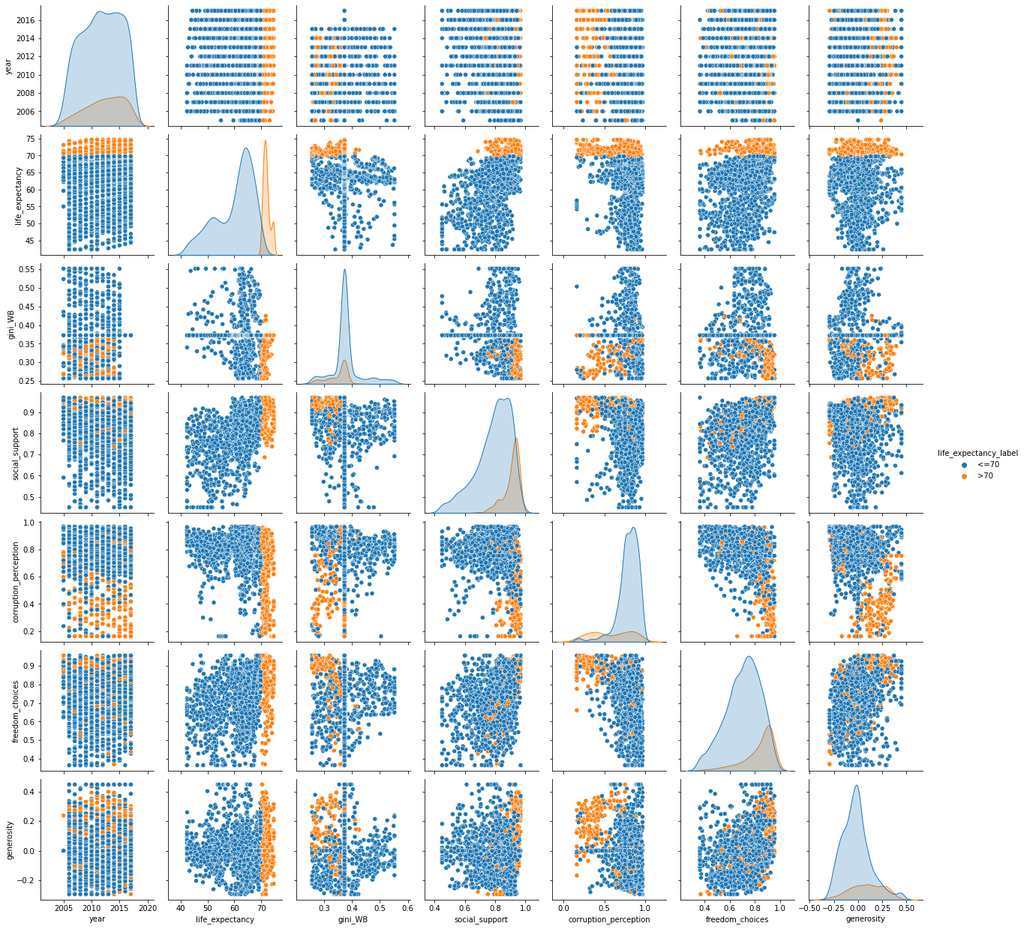

```python
df_sub = df[['year','life_expectancy', 'gini_WB', 'social_support', 'corruption_perception', 'freedom_choices', 'generosity','life_expectancy_label']].copy()
sns.pairplot(data = df_sub, hue = 'life_expectancy_label' )
```

### Regression Plot

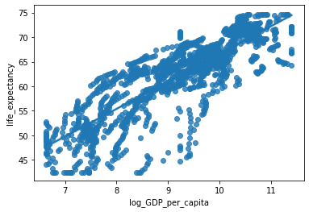

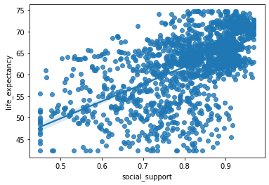

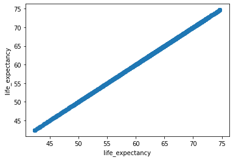

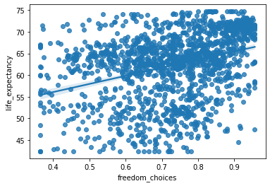

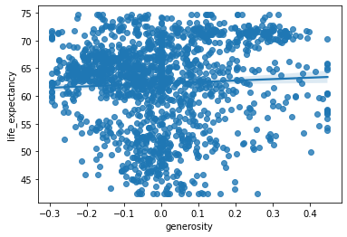

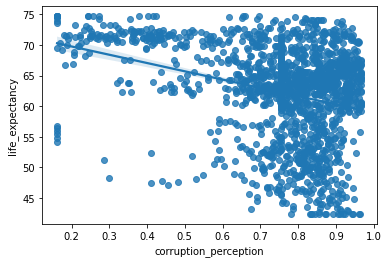

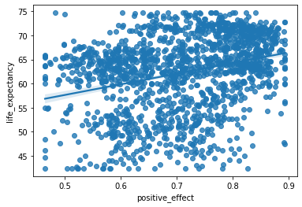

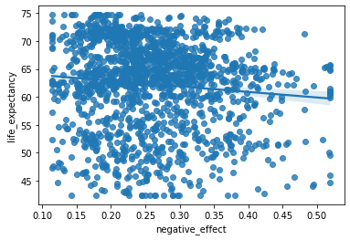

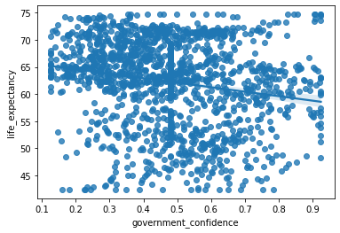

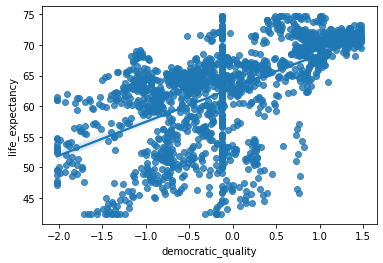

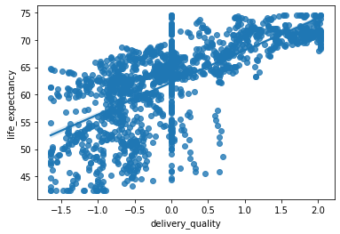

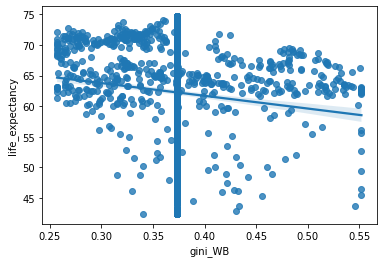

[2 more figures not shown]

```python
for column in column_names:
    plt.figure()
    sns.regplot(x = column, y = 'life_expectancy', data = df, ci = 95)
```

## Model Training

### Multiregression model

```python
df.columns
column_names = ['life_ladder', 'log_GDP_per_capita',
       'social_support', 'freedom_choices', 'generosity',
       'corruption_perception', 'positive_effect', 'negative_effect',
       'government_confidence', 'democratic_quality', 'delivery_quality']
```

```python
df_normalized = df.copy() # copying the dataframe

X = df_normalized[column_names]
y = df_normalized['life_expectancy']
```

```python
print(X)
print(y)
```

```
      life_ladder  log_GDP_per_capita  social_support  freedom_choices  \
0        3.723590            7.168690        0.450662         0.718114
1        4.401778            7.333790        0.552308         0.678896
2        4.758381            7.386629        0.539075         0.600127
3        3.831719            7.415019        0.521104         0.495901
4        3.782938            7.517126        0.520637         0.530935
...           ...                 ...             ...              ...
1557     4.690188            7.565154        0.799274         0.575884
1558     4.184451            7.562753        0.765839         0.642034
1559     3.703191            7.556052        0.735800         0.667193
1560     3.735400            7.538829        0.768425         0.732971
1561     3.638300            7.538187        0.754147         0.752826

      generosity  corruption_perception  positive_effect  negative_effect  \
0       0.181819               0.881686         0.517637         0.258195
```

[output cut: 37 more lines]

```python
X_train, X_test, y_train, y_test = train_test_split(X, y, test_size = 0.3,random_state = 1234)
```

```python
print(X_train.shape)
print(X_test.shape)
```

```
(1093, 11)
(469, 11)
```

```python
# Model training
model = LinearRegression() #no hyperparameters
model.fit(X_train,y_train)

prediction = model.predict(X_test)
```

```python
print('Model Summary:\n')

print('Intercept:')
print('alpha = ' , model.intercept_)

# Printing the weights that different parameters add to the model
print('\nWeights:')
i = 0
for w in model.coef_:
    print('w_',i+1,'= ', w, ' [ weight of ', column_names[i],']')
    i += 1
```

```
Model Summary:

Intercept:
alpha =  21.590961708390594

Weights:
w_ 1 =  1.3836931913078234  [ weight of  life_ladder ]
w_ 2 =  3.7939849897715527  [ weight of  log_GDP_per_capita ]
w_ 3 =  0.5444246602489426  [ weight of  social_support ]
w_ 4 =  1.3402433007513204  [ weight of  freedom_choices ]
w_ 5 =  0.8070354764691233  [ weight of  generosity ]
w_ 6 =  0.04599995213654018  [ weight of  corruption_perception ]
w_ 7 =  -3.3635380659709746  [ weight of  positive_effect ]
w_ 8 =  3.554204486149732  [ weight of  negative_effect ]
w_ 9 =  -3.8656614817340023  [ weight of  government_confidence ]
w_ 10 =  -0.16633849195606265  [ weight of  democratic_quality ]
w_ 11 =  1.376216906298403  [ weight of  delivery_quality ]
```

```python
# The mean squared error for multiple regression
mr_rmse = mean_squared_error(y_test, prediction, squared = False)
mr_r2 = r2_score(y_test, prediction)
print('\nModel Performance\n\nRMSE =   %.3f'
      % mr_rmse)
# The coefficient of determination
print(' R^2 =   %.3f'
      % mr_r2)
```

```
Model Performance

RMSE =   3.854
 R^2 =   0.762
```

### OLS Regression (Simple Linear Regression)

```
Model Summary for  life_ladder

Weight =   5.00004746337455 [ weight of feature: life_ladder  ]
Alpha =  35.29288521069044 [ intercept ]

Model Summary for  log_GDP_per_capita

Weight =   5.587345756465542 [ weight of feature: log_GDP_per_capita  ]
Alpha =  10.849347958682337 [ intercept ]

Model Summary for  social_support

Weight =   40.10020095243395 [ weight of feature: social_support  ]
Alpha =  29.897485465505504 [ intercept ]

Model Summary for  freedom_choices

Weight =   18.10448672420675 [ weight of feature: freedom_choices  ]
Alpha =  49.347030808324604 [ intercept ]

Model Summary for  generosity

Weight =   1.5286642444489646 [ weight of feature: generosity  ]
Alpha =  62.63426089744073 [ intercept ]

Model Summary for  corruption_perception

Weight =   -12.907310124088754 [ weight of feature: corruption_perception  ]
Alpha =  72.33850465680052 [ intercept ]

Model Summary for  positive_effect

Weight =   19.391134857461708 [ weight of feature: positive_effect  ]
Alpha =  48.793828200930335 [ intercept ]

Model Summary for  negative_effect

Weight =   -9.324654140824984 [ weight of feature: negative_effect  ]
Alpha =  65.06280311286886 [ intercept ]

Model Summary for  government_confidence

Weight =   -7.997148561280471 [ weight of feature: government_confidence  ]
Alpha =  66.4651499235437 [ intercept ]

Model Summary for  democratic_quality

Weight =   5.394792746244312 [ weight of feature: democratic_quality  ]
Alpha =  63.17152194522956 [ intercept ]

Model Summary for  delivery_quality

Weight =   5.756564544045377 [ weight of feature: delivery_quality  ]
Alpha =  62.42135709329236 [ intercept ]
```

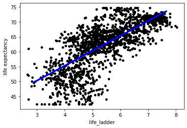

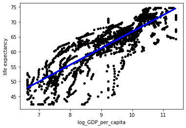

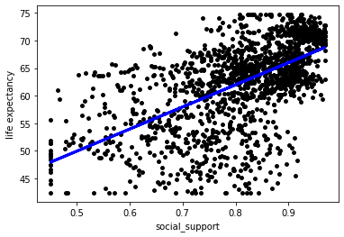

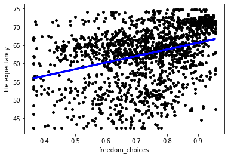

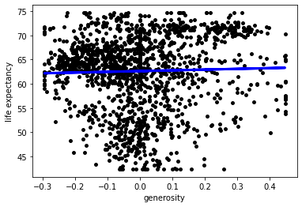

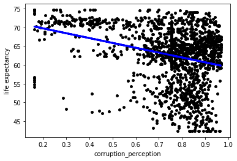

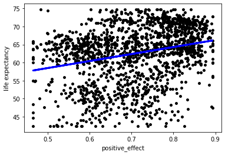

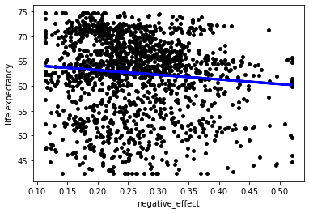

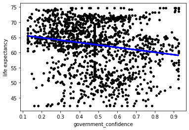

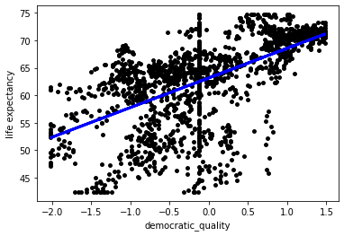

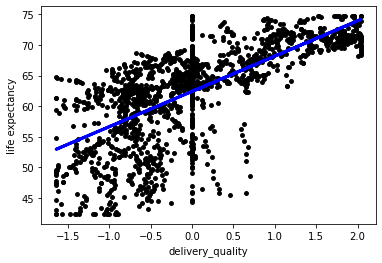

```python
column_names = ['life_ladder', 'log_GDP_per_capita',
       'social_support', 'freedom_choices', 'generosity',
       'corruption_perception', 'positive_effect', 'negative_effect',
       'government_confidence', 'democratic_quality', 'delivery_quality']

for column in column_names:
    X = df[column].to_frame()
    y = df['life_expectancy']

    #Train test split
    X_train, X_test, y_train, y_test = train_test_split(X, y, test_size = 0.3, random_state=123)

    #Training the model
    ols_model = LinearRegression()
    ols_model.fit(X_train,y_train)
    prediction = ols_model.predict(X_test)
    print('\nModel Summary for ',column,'\n\nWeight =  ', ols_model.coef_[0], '[ weight of feature:',column, ' ]')
    print('Alpha = ', ols_model.intercept_, '[ intercept ]')

    #visualize
    plt.figure()
    plt.scatter(X, y,  color='black',s=15);
    plt.plot(X_test, prediction, color='blue', linewidth=3);
    plt.xlabel(column);
    plt.ylabel('life expectancy');
```